# Plan

2025-04-15

## Introduction

If you’re anything like us, you’ve probably spent hours scrolling through Netflix, Prime Video, Disney+, and Hulu, trying to decide what to watch. With so many options available, it’s easy to feel overwhelmed, especially when it comes to choosing between the platforms. That’s where this analysis comes in—we’re diving into the Rotten Tomatoes scores across these platforms to see which one consistently delivers the highest-rated content. By comparing these ratings, we want to make it easier for you to figure out which platform offers the best movies and shows based on critical reviews, so you can make more confident choices next time you’re deciding what to watch.

## Questions

1. How many titles are available on each platform?
2. Which platform has the highest-rated content overall (based on Rotten Tomatoes scores)?
3. How has the number of titles released over time changed for each platform?
4. Which platform has the most highly rated content (RT score > 90%)?
5. How do age ratings vary across platforms?
6. Which platforms focus more on older vs. newer titles?
7. How do average Rotten Tomatoes scores differ by age rating?
8. How have average Rotten Tomatoes scores changed over time per platform?
9. Which age ratings are underrepresented on each platform?

## Packages Used

```r
library(tidyverse)
library(dplyr)
library(janitor)
```

## Unfiltered Data

Data set : https://www.kaggle.com/datasets/sanyacodes/movies-dataset-netflix-prime-video-disney

```r
streaming_data <- read_csv("MoviesOnStreamingPlatforms 2.csv") %>% clean_names()
```

```
## ──────────────────────────────────────────────────────── Delimiter: "," chr
## (3): Title, Age, Rotten Tomatoes dbl (8): ...1, ID, Year, Netflix, Hulu, Prime
## Video, Disney+, Type
```

```r
glimpse(streaming_data)
```

```
## Rows: 9,515
## Columns: 11
## $ x1              <dbl> 0, 1, 2, 3, 4, 5, 6, 7, 8, 9, 10, 11, 12, 13, 14, 15, …
## $ id              <dbl> 1, 2, 3, 4, 5, 6, 7, 8, 9, 10, 11, 12, 13, 14, 15, 16,…
## $ title           <chr> "The Irishman", "Dangal", "David Attenborough: A Life …
## $ year            <dbl> 2019, 2016, 2020, 2001, 2018, 2018, 2020, 2017, 2018, …
## $ age             <chr> "18+", "7+", "7+", "7+", "18+", "13+", "13+", "13+", "…
## $ rotten_tomatoes <chr> "98/100", "97/100", "95/100", "94/100", "94/100", "94/…
## $ netflix         <dbl> 1, 1, 1, 1, 1, 1, 1, 1, 1, 1, 1, 1, 1, 1, 1, 1, 1, 1, …
## $ hulu            <dbl> 0, 0, 0, 0, 0, 0, 0, 0, 0, 0, 0, 0, 0, 0, 0, 0, 0, 0, …
## $ prime_video     <dbl> 0, 0, 0, 0, 0, 0, 0, 0, 0, 0, 0, 0, 0, 0, 0, 0, 0, 0, …
## $ disney          <dbl> 0, 0, 0, 0, 0, 0, 0, 0, 0, 0, 0, 0, 0, 0, 0, 0, 0, 0, …
## $ type            <dbl> 0, 0, 0, 0, 0, 0, 0, 0, 0, 0, 0, 0, 0, 0, 0, 0, 0, 0, …
```

## Key Terms for Unfiltered Data & Filtered Data

- ID: A unique identifier for each movie within the dataset. Title: The full title of the movie as it appears on the streaming platforms.
- Year: The release year of the movie, indicating when the movie was first made available to the public.
- Age: The recommended age group for the movie’s audience, such as ‘7+’, ‘13+’, ‘16+’, or ‘18+’.
- Rotten Tomatoes: The movie’s score on Rotten Tomatoes, which reflects critics’ reviews and can be used as a measure of the movie’s reception.
- Netflix, Hulu, Prime Video, Disney + : A binary indicator (0 or 1) of whether the movie is available on the streaming service, with 1 indicating availability.
- Type: A categorical indicator distinguishing the content as either a ‘Movie’ or a ‘TV Show’.

## Introduction to the Data

Streaming platforms are now the go-to for watching movies and shows, and each one has its own unique library. With all the competition for content, it’s more important than ever to understand what sets these platforms apart — not just in what they have, but in the quality and variety of their offerings. This dataset gives us a snapshot of what’s available on Netflix, Prime Video, Disney+, and Hulu. By exploring the data, we can spot each platform’s strengths, see trends in genres and quality, and help people or companies make smarter choices when it comes to content.

### Questions We Plan to Ask (and Graphs to Make)

1. Which platform has the highest-rated content overall (based on Rotten Tomatoes scores)?

Bar graph comparing average Rotten Tomatoes score for each platform

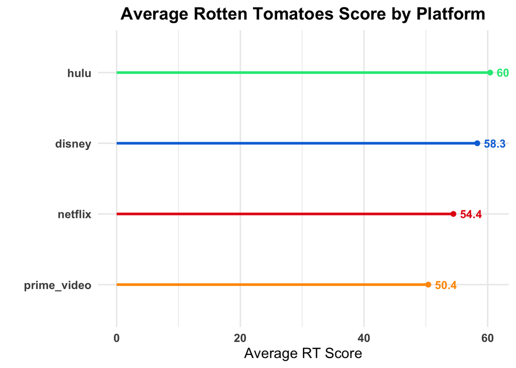

```r
highest_rated <- streaming_data %>%
  filter(!is.na(rotten_tomatoes)) %>%
  mutate(rotten_tomatoes = as.numeric(gsub("/100", "", rotten_tomatoes))) %>%
  pivot_longer(
    cols = c(netflix, hulu, disney, prime_video),
    names_to = "Platform",
    values_to = "Available"
  ) %>%
  filter(Available == 1) %>%
  group_by(Platform) %>%
  summarise(avg_score = mean(rotten_tomatoes, na.rm = TRUE), .groups = "drop")

ggplot(highest_rated, aes(x = reorder(Platform, avg_score), y = avg_score, color = Platform)) +
  geom_segment(aes(xend = Platform, y = 0, yend = avg_score), size = 1.2) +  # the stick
  geom_point(size = 2) +  # the lollipop head
  geom_text(aes(label = round(avg_score, 1)), hjust = -0.3, fontface = "bold") +  # labels to the right
  scale_color_manual(values = c(
    "netflix" = "#E50914",
    "hulu" = "#1CE783",
    "disney" = "#0A74DA",
    "prime_video" = "#FF9900"
  )) +
  labs(
    title = "Average Rotten Tomatoes Score by Platform",
    x = "",
    y = "Average RT Score"
  ) +
  coord_flip() +  # Flip chart horizontally
  theme_minimal(base_size = 14) +
  theme(
    plot.title = element_text(hjust = 0.5, face = "bold"),
    axis.text.x = element_text(face = "bold"),
    axis.text.y = element_text(face = "bold"),
    legend.position = "none"
  )
```

```r
highest_rated
```

```
## # A tibble: 4 × 2
##   Platform    avg_score
##   <chr>           <dbl>
## 1 disney           58.3
## 2 hulu             60.4
## 3 netflix          54.4
## 4 prime_video      50.4
```

How many titles are available on each platform? Bar graph showing total number of titles per platform

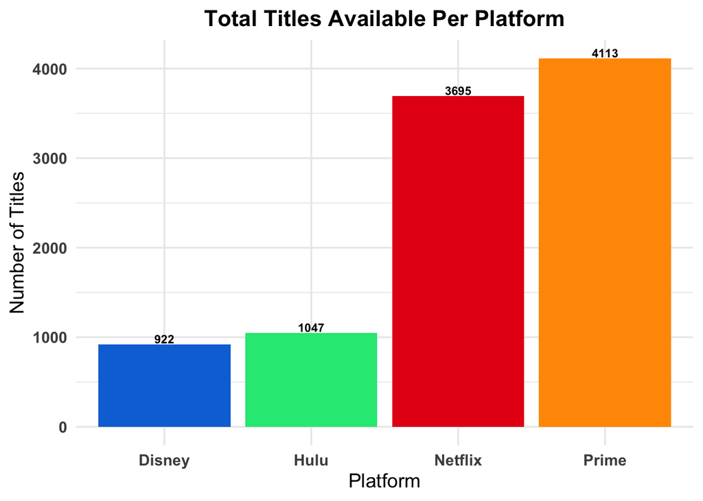

```r
titles_available <- streaming_data %>%
  summarise(
    Netflix = sum(netflix, na.rm = TRUE),
    Hulu = sum(hulu, na.rm = TRUE),
    Disney = sum(disney, na.rm = TRUE),
    Prime = sum(prime_video, na.rm = TRUE)
  ) %>%
  pivot_longer(cols = everything(), names_to = "Platform", values_to = "Count") %>%
  ggplot(aes(x = Platform, y = Count, fill = Platform)) +
  geom_bar(stat = "identity") +
  geom_text(aes(label = Count), vjust = -.15, fontface = "bold", size= 3) +  # <-- Adds labels
  scale_fill_manual(values = c(
    "Netflix" = "#E50914",
    "Hulu" = "#1CE783",
    "Disney" = "#0A74DA",
    "Prime" = "#FF9900"
  )) +
  labs(
    title = "Total Titles Available Per Platform",
    x = "Platform",
    y = "Number of Titles"
  ) +

  theme_minimal(base_size = 14) +
  theme(
    plot.title = element_text(hjust = 0.5, face = "bold", size = 16),
    axis.text.x = element_text(face = "bold"),
    axis.text.y = element_text(face = "bold"),
    legend.position = "none"
  )
titles_available
```

How has the number of titles released over time changed for each platform? Line graph showing number of titles per release year, grouped by platform

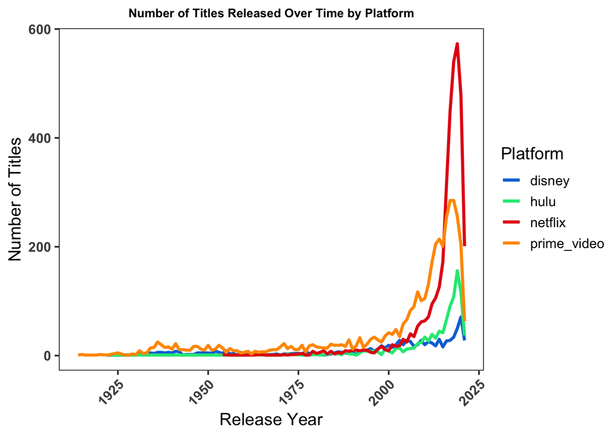

```r
titles_over_time <- streaming_data %>%
  select(title, year, netflix, hulu, disney, prime_video) %>%
  pivot_longer(
    cols = c(netflix, hulu, disney, prime_video),
    names_to = "Platform",
    values_to = "Available"
  ) %>%
  filter(Available == 1, !is.na(year)) %>%
  group_by(year, Platform) %>%
  summarise(Count = n(), .groups = "drop")

ggplot(titles_over_time, aes(x = year, y = Count, color = Platform)) +
  geom_line(size = 1.2) +
  scale_color_manual(values = c(
    "netflix" = "#E50914",
    "hulu" = "#1CE783",
    "disney" = "#0A74DA",
    "prime_video" = "#FF9900"
  )) +
  labs(
    title = "Number of Titles Released Over Time by Platform",
    x = "Release Year",
    y = "Number of Titles",
    color = "Platform"
  ) +
  theme_test(base_size = 14) +
  theme(
    plot.title = element_text(hjust = 0.5, size = 10, face = "bold"),
    axis.text.x = element_text(angle = 45, hjust = 1, face = "bold"),
    axis.text.y = element_text(face = "bold")
  )
```

Which platform has the most highly rated content (RT score > 90%)? Bar chart showing count of high-rated titles per platform

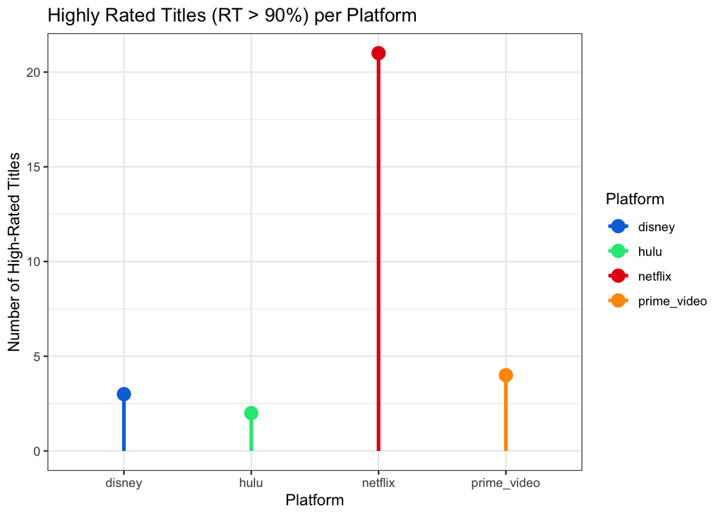

```r
high_rated <- streaming_data %>%
  filter(rotten_tomatoes > 90)

high_rated_counts <- high_rated %>%
  pivot_longer(
    cols = c(netflix, hulu, disney, prime_video),
    names_to = "Platform",
    values_to = "Available"
  ) %>%
  filter(Available == 1) %>%
  group_by(Platform) %>%
  summarise(Count = n()) %>%
  ungroup()

ggplot(high_rated_counts, aes(x = Platform, y = Count, color = Platform)) +
  geom_segment(aes(x = Platform, xend = Platform, y = 0, yend = Count), size = 1.2) +
  geom_point(size = 4) +
  scale_color_manual(values = c(
    "netflix" = "#E50914",
    "hulu" = "#1CE783",
    "disney" = "#0A74DA",
    "prime_video" = "#FF9900"
  )) +
  labs(
    title = "Highly Rated Titles (RT > 90%) per Platform",
    x = "Platform",
    y = "Number of High-Rated Titles"
  ) +
  theme_bw()
```

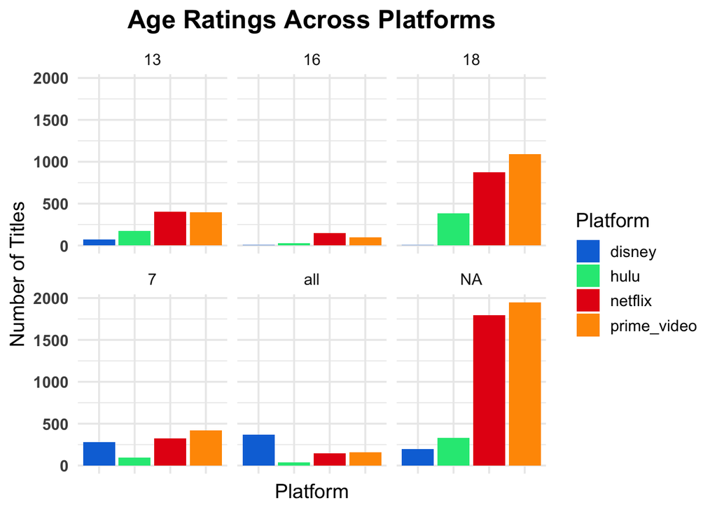

```r
age_rating_counts <- streaming_data %>%
  select(title, netflix, hulu, disney, prime_video, age) %>%
  pivot_longer(
    cols = c(netflix, hulu, disney, prime_video),
    names_to = "Platform",
    values_to = "Available"
  ) %>%
  filter(Available == 1) %>%  # Only titles that are available on a platform
  mutate(age_clean = gsub("\\+", "", age)) %>%  # Remove the '+' symbol
  group_by(Platform, age_clean) %>%
  summarise(Count = n(), .groups = "drop")  # Count number of titles for each age group

ggplot(age_rating_counts, aes(x = Platform, y = Count, fill = Platform)) +
  geom_bar(stat = "identity") +
  facet_wrap(~ age_clean) +  # Facet by age rating
  scale_fill_manual(values = c(
    "netflix" = "#E50914",
    "hulu" = "#1CE783",
    "disney" = "#0A74DA",
    "prime_video" = "#FF9900")) +  # Use platform-specific colors
  labs(
    title = "Age Ratings Across Platforms",
    x = "Platform",
    y = "Number of Titles",
    fill = "Platform"
  ) +
  theme_minimal(base_size = 14) +
  theme(
    plot.title = element_text(hjust = 0.5, size = 18, face = "bold"),
    axis.text.x = element_blank(),
    axis.ticks.x = element_blank(),
    axis.text.y = element_text(face = "bold")
  )
```

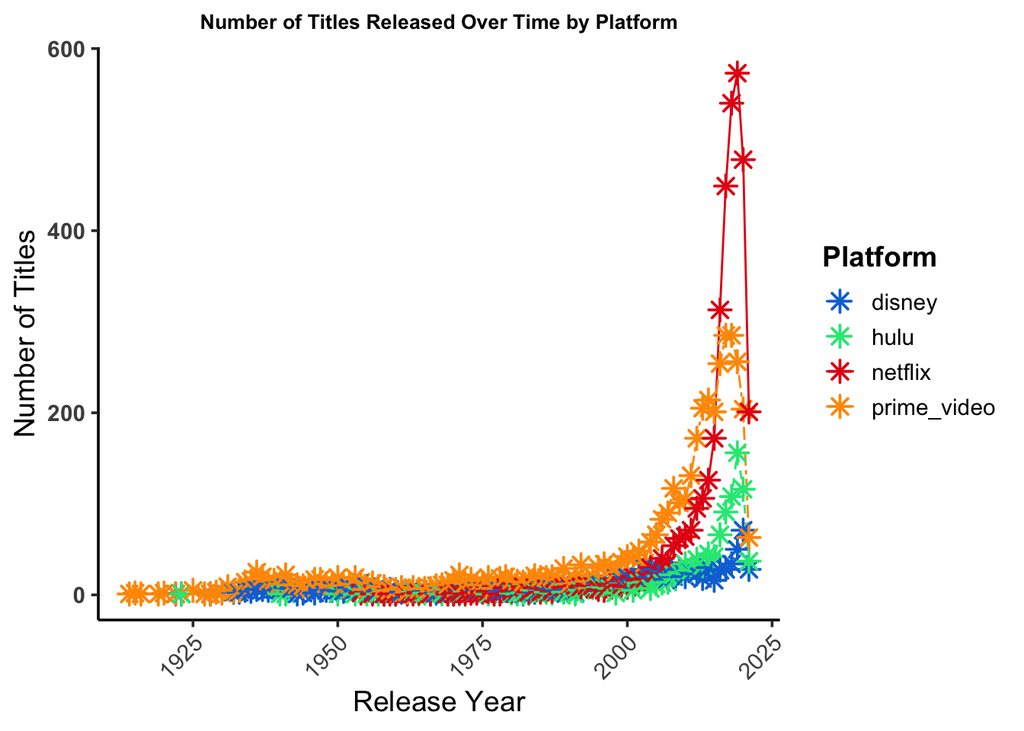

```r
release_year_line <- streaming_data %>%
  select(title, year, netflix, hulu, disney, prime_video) %>%
  pivot_longer(
    cols = c(netflix, hulu, disney, prime_video),
    names_to = "Platform",
    values_to = "Available"
  ) %>%
  filter(Available == 1, !is.na(year)) %>%
  group_by(year, Platform) %>%
  summarise(Count = n(), .groups = "drop") %>%
  ggplot(aes(x = year, y = Count, color = Platform, linetype = Platform)) +
  geom_line(size = .5) +
  geom_point(size = 3, shape = 8, fill = "white", stroke = 1) +
  scale_color_manual(values = c(
    "netflix" = "#E50914",
    "hulu" = "#1CE783",
    "disney" = "#0A74DA",
    "prime_video" = "#FF9900")) +
  scale_linetype_manual(values = c(
    "netflix" = "solid",
    "hulu" = "dashed",
    "disney" = "dotdash",
    "prime_video" = "twodash")) +
  labs(
    title = "Number of Titles Released Over Time by Platform",
    x = "Release Year",
    y = "Number of Titles",
    color = "Platform",
    linetype = "Platform"
  ) +
  theme_classic(base_size = 14) +
  theme(
    plot.title = element_text(hjust = 0.5, size = 10, face = "bold"),
    axis.text.x = element_text(angle = 45, hjust = 1),
    axis.text.y = element_text(face = "bold"),
    legend.title = element_text(face = "bold")
  )

release_year_line
```

How do average Rotten Tomatoes scores differ by age rating? Boxplot or bar chart showing average score per age group

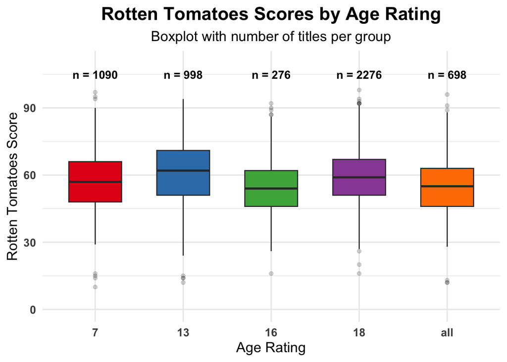

```r
age_counts <- streaming_data %>%
  filter(!is.na(age), !is.na(rotten_tomatoes)) %>%
  mutate(
    age_clean = gsub("\\+", "", age),
    age_clean = factor(age_clean, levels = c("7", "13", "16", "18", "all")),
    rotten_tomatoes = as.numeric(gsub("/100", "", rotten_tomatoes))
  ) %>%
  count(age_clean)

boxplot_ratings <- streaming_data %>%
  filter(!is.na(age), !is.na(rotten_tomatoes)) %>%
  mutate(
    age_clean = gsub("\\+", "", age),
    age_clean = factor(age_clean, levels = c("7", "13", "16", "18", "all")),
    rotten_tomatoes = as.numeric(gsub("/100", "", rotten_tomatoes))
  ) %>%
  ggplot(aes(x = age_clean, y = rotten_tomatoes, fill = age_clean)) +


  geom_boxplot(outlier.alpha = 0.2, width = 0.6) +

  geom_text(
    data = age_counts,
    aes(x = age_clean, y = 105, label = paste0("n = ", n)),
    inherit.aes = FALSE,
    fontface = "bold",
    size = 4
  ) +

  scale_fill_brewer(palette = "Set1") +
  coord_cartesian(ylim = c(0, 110)) +
  labs(
    title = "Rotten Tomatoes Scores by Age Rating",
    subtitle = "Boxplot with number of titles per group",
    x = "Age Rating",
    y = "Rotten Tomatoes Score",
    fill = "Age Rating"
  ) +
  theme_minimal(base_size = 14) +
  theme(
    plot.title = element_text(hjust = 0.5, size = 18, face = "bold"),
    plot.subtitle = element_text(hjust = 0.5),
    axis.text.x = element_text(face = "bold"),
    axis.text.y = element_text(face = "bold"),
    legend.position = "none"
  )

boxplot_ratings
```

How have average Rotten Tomatoes scores changed over time per platform? Line graph of average score by year for each platform

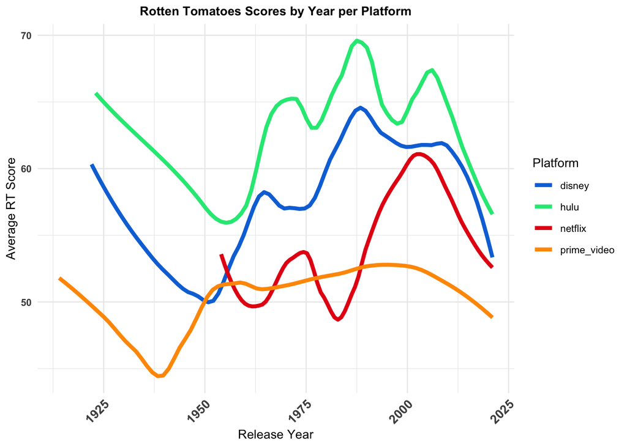

```r
avg_score_over_time <- streaming_data %>%
  filter(!is.na(year), !is.na(rotten_tomatoes)) %>%
  mutate(
    rotten_tomatoes = as.numeric(gsub("/100", "", rotten_tomatoes)),
    age_clean = gsub("\\+", "", age)
  ) %>%
  filter(!is.na(rotten_tomatoes)) %>%
  pivot_longer(
    cols = c(netflix, hulu, disney, prime_video),
    names_to = "Platform",
    values_to = "Available"
  ) %>%
  filter(Available == 1) %>%
  group_by(year, Platform) %>%
  summarise(avg_rotten_tomatoes = mean(rotten_tomatoes, na.rm = TRUE), .groups = "drop") %>%
  ggplot(aes(x = year, y = avg_rotten_tomatoes, color = Platform)) +


  geom_smooth(se = FALSE, method = "loess", span = 0.4, size = 1.5) +


  scale_color_manual(values = c(
    "netflix" = "#E50914",
    "hulu" = "#1CE783",
    "disney" = "#0A74DA",
    "prime_video" = "#FF9900")) +

  labs(
    title = "Rotten Tomatoes Scores by Year per Platform",
    x = "Release Year",
    y = "Average RT Score",
    color = "Platform"
  ) +
  theme_minimal(base_size = 10) +
  theme(
    plot.title = element_text(hjust = 0.5, size = 10, face = "bold"),
    axis.text.x = element_text(angle = 45,face = "bold", size = 10, hjust = 1),
    axis.text.y = element_text(face = "bold")
  )

avg_score_over_time
```

Which age ratings are underrepresented on each platform? Heatmap or bar chart showing low-count age groups per platform

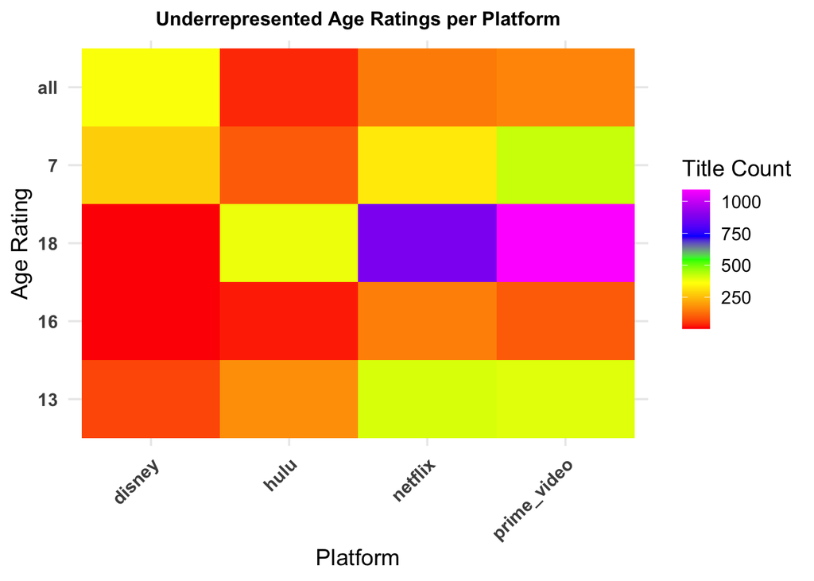

```r
age_rating_counts <- streaming_data %>%
  filter(!is.na(age), !is.na(rotten_tomatoes)) %>%  # Remove rows with NA values for age and rotten_tomatoes
  mutate(age_clean = gsub("\\+", "", age)) %>%  # Clean age rating by removing the '+' symbol
  pivot_longer(
    cols = c(netflix, hulu, disney, prime_video),
    names_to = "Platform",
    values_to = "Available"
  ) %>%
  filter(Available == 1) %>%  # Only keep titles that are available on a platform
  group_by(Platform, age_clean) %>%
  summarise(Count = n(), .groups = "drop")  # Count the number of titles for each age group per platform

ggplot(age_rating_counts, aes(x = Platform, y = age_clean, fill = Count)) +
  geom_tile() +
  scale_fill_gradientn(
    colors = c("red", "orange", "yellow", "green", "blue", "purple", "magenta")
  ) +
  labs(
    title = "Underrepresented Age Ratings per Platform",
    x = "Platform",
    y = "Age Rating",
    fill = "Title Count"
  ) +
  theme_minimal(base_size = 14) +
  theme(
    plot.title = element_text(hjust = 0.5, size = 12, face = "bold"),
    axis.text.x = element_text(angle = 45, hjust = 1, face = "bold"),
    axis.text.y = element_text(face = "bold")
  )
```

## Key Values and Calculations:

- The dataset spans over a century of movie releases, from as early as 1914 to 2021.
- With 9515 unique values for movie titles, the dataset covers a wide range of cinematic works, from classics to recent releases.

## Q1. How many titles are available on each platform?

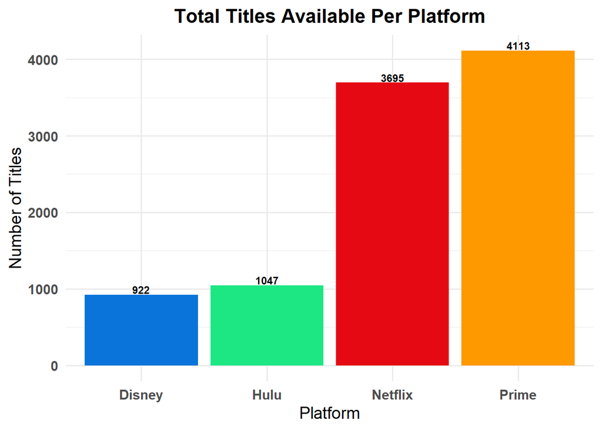

## Q2. Which platform has the highest-rated content overall (based on Rotten Tomatoes scores)?

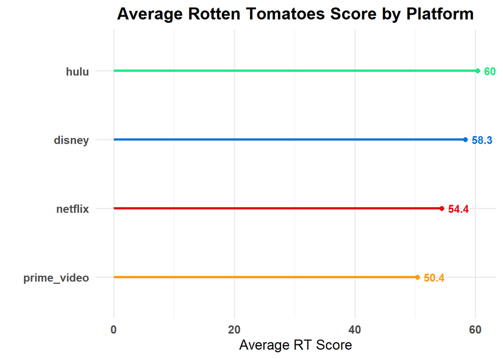

```
## # A tibble: 4 × 2
##   Platform    avg_score
##   <chr>           <dbl>
## 1 disney           58.3
## 2 hulu             60.4
## 3 netflix          54.4
## 4 prime_video      50.4
```

## Q3. How has the number of titles released over time changed for each platform?

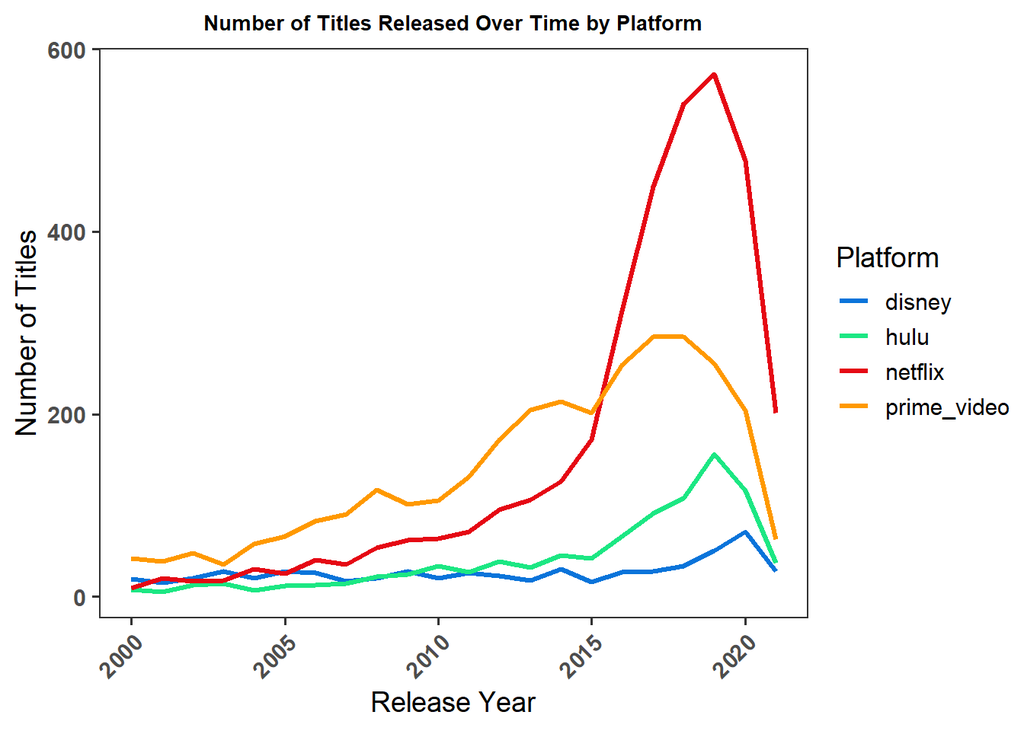

## Q4. Which platform has the most highly rated content (RT score > 90%)?

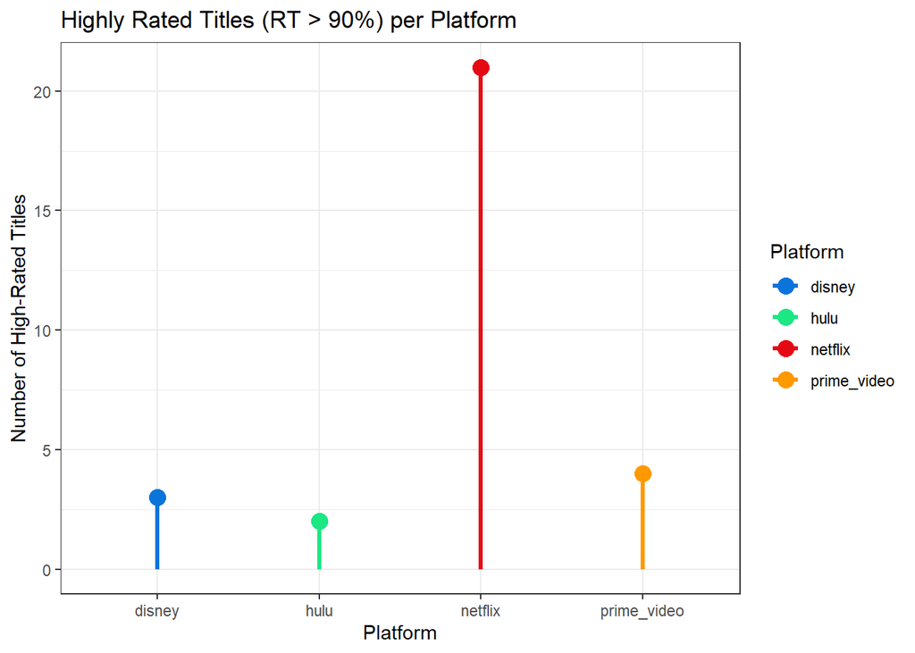

## Q5. How do age ratings vary across platforms?

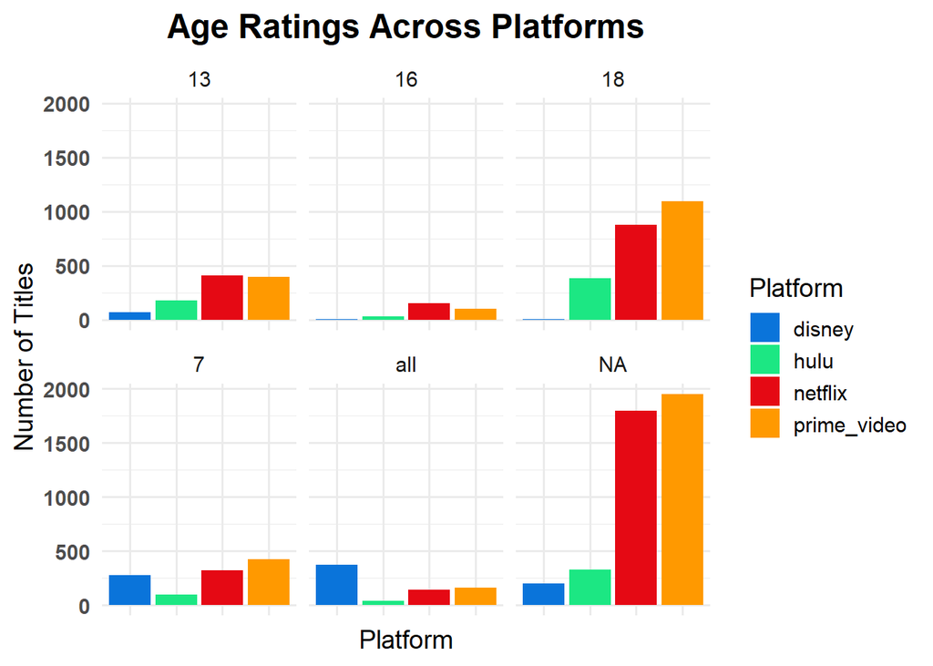

## Q6. Which platforms focus more on older vs. newer titles?

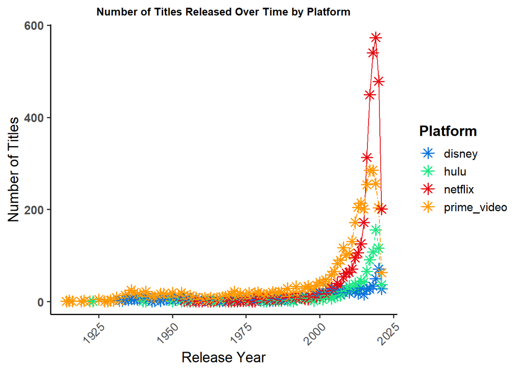

## Q7. How do average Rotten Tomatoes scores differ by age rating?

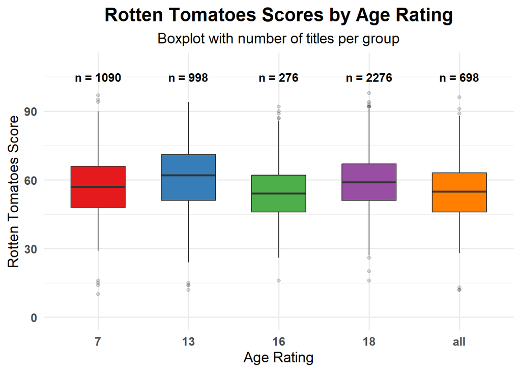

## Q8. How have average Rotten Tomatoes scores changed over time per platform?

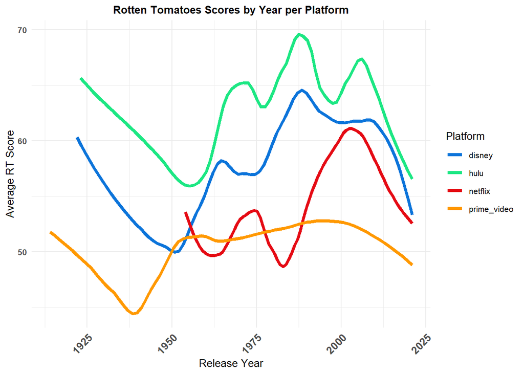

## Q9. Which age ratings are underrepresented on each platform?

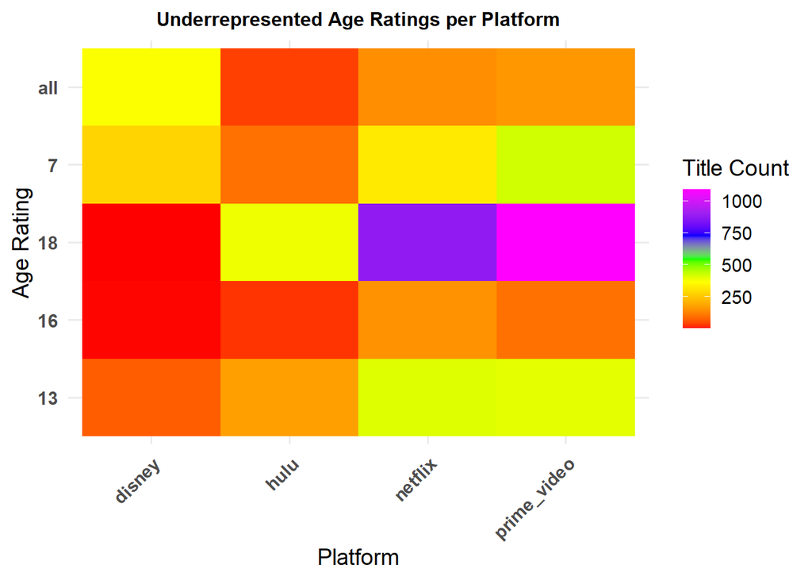